# FINAL PROJECT - DRUG CONSUMPTION ANALYSIS

# Projet Python DIA5

### Description des caractéristiques démographiques et de personnalité

|  | Age | Genre | Education | Neuroticisme | Extraversion | Ouverture à l'expérience | Agréabilité | Sérieux | Impulsivité | Recherche de sensation | Alcool | Amphetamine | Amyl nitrite | Benzodiazepine | Caffeine | Cannabis | Chocolat | Cocaine | Crack | Ecstasy | Heroin | Ketamine | Substance psychoactive | LSD | Methadone | Champignon hallucinogène | Nicotine | Substance Volatile |
| --- | --- | --- | --- | --- | --- | --- | --- | --- | --- | --- | --- | --- | --- | --- | --- | --- | --- | --- | --- | --- | --- | --- | --- | --- | --- | --- | --- | --- |
| count | 1877.000000 | 1877.000000 | 1877.000000 | 1877.000000 | 1877.000000 | 1877.000000 | 1877.000000 | 1877.000000 | 1877.000000 | 1877.000000 | 1877.000000 | 1877.000000 | 1877.000000 | 1877.000000 | 1877.000000 | 1877.000000 | 1877.000000 | 1877.000000 | 1877.000000 | 1877.000000 | 1877.000000 | 1877.000000 | 1877.000000 | 1877.000000 | 1877.000000 | 1877.000000 | 1877.000000 | 1877.000000 |
| mean | 0.037577 | 0.500799 | -0.000984 | -0.000551 | -0.001951 | -0.003224 | -0.000657 | -0.000394 | 0.005293 | -0.007408 | 4.637720 | 1.337773 | 0.606819 | 1.461907 | 5.484283 | 2.980288 | 5.109750 | 1.156633 | 0.295685 | 1.309536 | 0.372403 | 0.564198 | 1.353223 | 1.053277 | 0.826319 | 1.177944 | 3.194992 | 0.429409 |
| std | 0.878387 | 0.500133 | 0.949831 | 0.998442 | 0.997418 | 0.995691 | 0.996689 | 0.997657 | 0.954148 | 0.962074 | 1.328234 | 1.782384 | 1.064005 | 1.869193 | 1.115119 | 2.286778 | 1.085716 | 1.510791 | 0.835925 | 1.647373 | 1.034761 | 1.216341 | 1.790881 | 1.484582 | 1.648379 | 1.459212 | 2.415814 | 0.959160 |
| min | -0.951970 | 0.000000 | -2.435910 | -3.464360 | -3.273930 | -3.273930 | -3.464360 | -3.464360 | -2.555240 | -2.078480 | 0.000000 | 0.000000 | 0.000000 | 0.000000 | 0.000000 | 0.000000 | 0.000000 | 0.000000 | 0.000000 | 0.000000 | 0.000000 | 0.000000 | 0.000000 | 0.000000 | 0.000000 | 0.000000 | 0.000000 | 0.000000 |
| 25% | -0.951970 | 0.000000 | -0.611130 | -0.678250 | -0.695090 | -0.717270 | -0.606330 | -0.652530 | -0.711260 | -0.525930 | 4.000000 | 0.000000 | 0.000000 | 0.000000 | 5.000000 | 1.000000 | 5.000000 | 0.000000 | 0.000000 | 0.000000 | 0.000000 | 0.000000 | 0.000000 | 0.000000 | 0.000000 | 0.000000 | 1.000000 | 0.000000 |
| 50% | -0.078540 | 1.000000 | -0.059210 | 0.042570 | 0.003320 | -0.019280 | -0.017290 | -0.006650 | -0.217120 | 0.079870 | 5.000000 | 0.000000 | 0.000000 | 0.000000 | 6.000000 | 3.000000 | 5.000000 | 0.000000 | 0.000000 | 0.000000 | 0.000000 | 0.000000 | 0.000000 | 0.000000 | 0.000000 | 0.000000 | 3.000000 | 0.000000 |
| 75% | 0.497880 | 1.000000 | 0.454680 | 0.629670 | 0.637790 | 0.723300 | 0.760960 | 0.584890 | 0.529750 | 0.765400 | 6.000000 | 2.000000 | 1.000000 | 3.000000 | 6.000000 | 5.000000 | 6.000000 | 2.000000 | 0.000000 | 3.000000 | 0.000000 | 0.000000 | 3.000000 | 2.000000 | 0.000000 | 2.000000 | 6.000000 | 0.000000 |
| max | 2.591710 | 1.000000 | 1.984370 | 3.273930 | 3.273930 | 2.901610 | 3.464360 | 3.464360 | 2.901610 | 1.921730 | 6.000000 | 6.000000 | 6.000000 | 6.000000 | 6.000000 | 6.000000 | 6.000000 | 6.000000 | 6.000000 | 6.000000 | 6.000000 | 6.000000 | 6.000000 | 6.000000 | 6.000000 | 6.000000 | 6.000000 | 6.000000 |

Pour que ces résultats soit plus lisibles et parlant, affichons-les sous forme de Box plots. On remarquera que les valeurs des colonnes des caractéristiques des individus sont centrées autour de 0. Les données ont donc été standardisées.

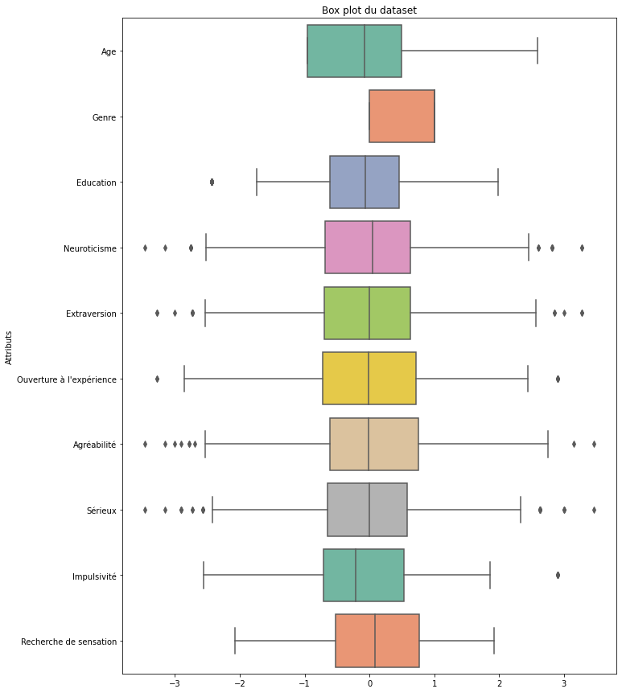

```python
fig, ax = plt.subplots(figsize=(11,15))
plt.ylabel("Attributs")
plt.title("Box plot du dataset")
ax = sns.boxplot(data = data[['Age', 'Genre', 'Education']+col_personnalité], orient="h", palette="Set2")
sns.reset_orig()
```

### Visualisation des proportions pour chaque caractéristique démographique et de personnalité

#### Caractéristiques démographiques

##### Rappel des différentes catégories :

###### Age :

- 0 : 18-24 ans
- 1 : 25-34 ans
- 2 : 35-44 ans
- 3 : 45-54 ans
- 4 : 55-64 ans
- 5 : 65+ ans

###### Education :

- 0 : Left school before 16 years
- 1 : Left school at 16 years
- 2 : Left school at 17 years
- 3 : Left school at 18 years
- 4 : Some college or university, no certificate or degree
- 5 : Professional certificate/ diploma
- 6 : University degree
- 7 : Masters degree
- 8 : Doctorate degree

###### Genre :

- 0 : homme
- 1 : femme

###### Pays :

- 0 : USA
- 1 : New Zealand
- 2 : Other
- 3 : Australia
- 4 : Republic of Ireland
- 5 : Canada
- 6 : UK

###### Ethnicité :

- 0 : Black
- 1 : Asian
- 2 : White
- 3 : Mixed-White/Asian
- 4 : Other
- 5 : Mixed-White/Black
- 6 : Mixed-Black/Asian

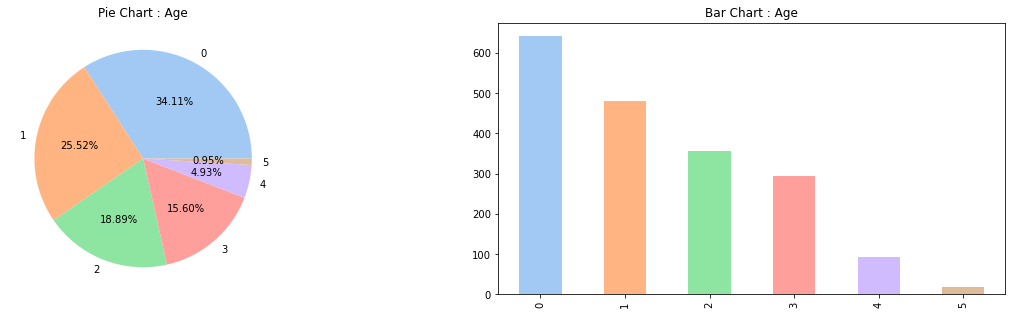

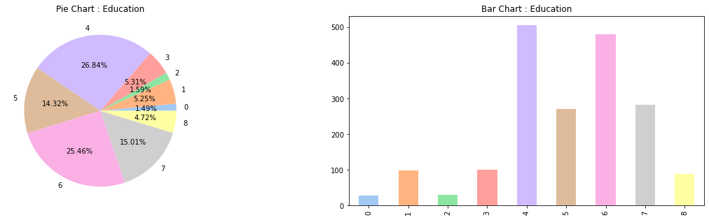

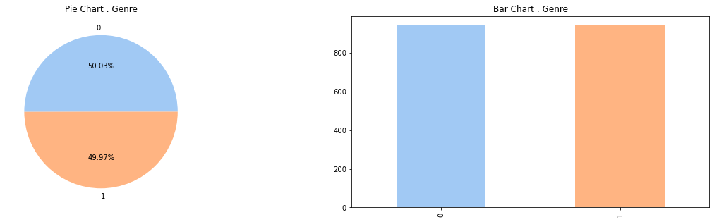

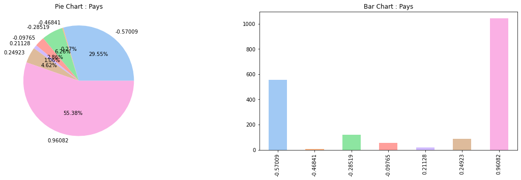

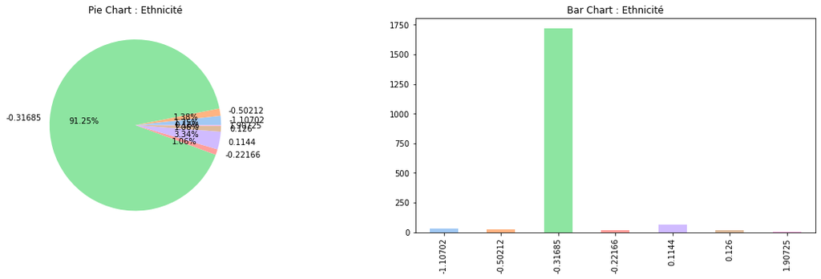

```python
visu(df, 'Age')
visu(df, 'Education')
visu(df, 'Genre')
visu(df, 'Pays')
visu(df, 'Ethnicité')
```

On utilisera donc le dataset sans ces les colonnes Pays et Ethnicité.

#### Caractéristiques de personnalité

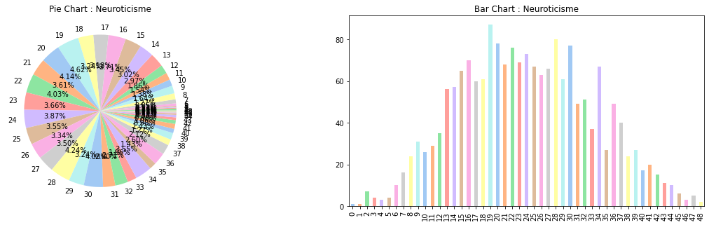

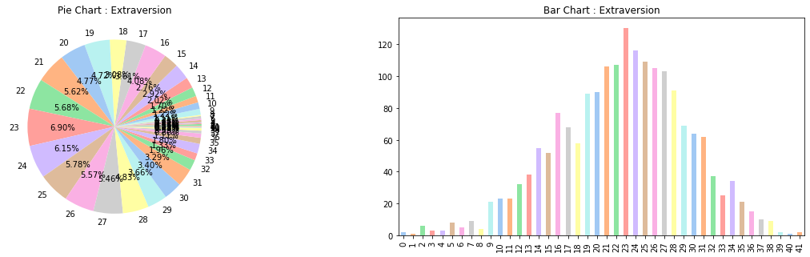

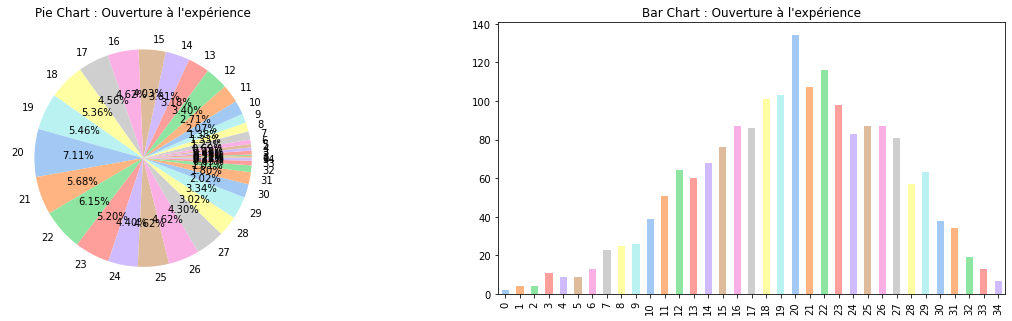

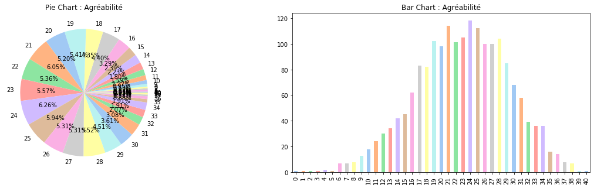

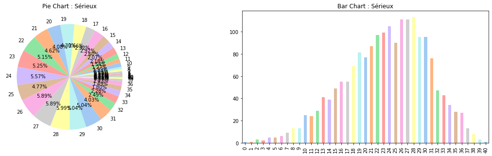

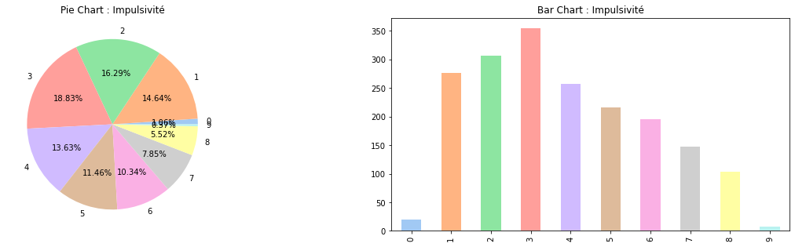

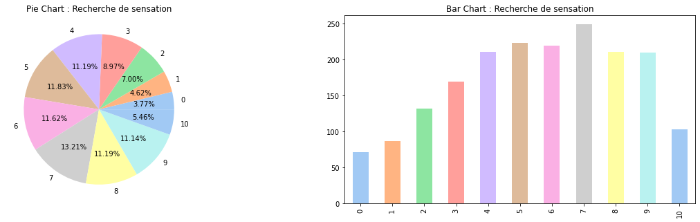

```python
visu(df, 'Neuroticisme')
visu(df, 'Extraversion')
visu(df, 'Ouverture à l\'expérience')
visu(df, 'Agréabilité')
visu(df, 'Sérieux')
visu(df, 'Impulsivité')
visu(df, 'Recherche de sensation')
```

Ces graphes sont difficiles à interpréter car il y a plusieurs niveaux pour ces traits de personnalité. On remarque toutefois grâce aux pie charts qu' il ne semble pas y avoir de déséquilibre important.

#### Corrélation entre les différents traits de personnalité

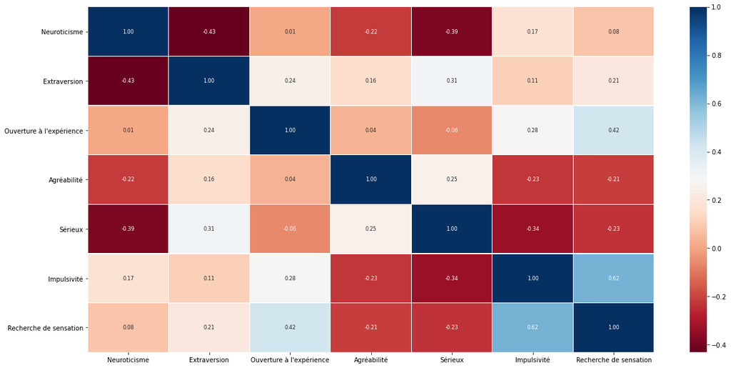

```python
corr = data[col_personnalité].corr()
plt.figure(figsize=(20,10))
sns.heatmap(corr, cmap='RdBu',annot=True, annot_kws={"fontsize":8}, linewidth = 0.1, fmt='.2f')
```

Aucune corrélation forte, mais quelques corrélations modérées. Le signe de la corrélation peut être intéressant à prendre en compte.

Le neuroticisme, par exemple, a peu de corrélations positives avec les autres traits de personnalité. Il présente une corrélation descendante faible-modérée avec l'extraversion et le sérieux.

#### Visualisation du nombre de consommateurs par classe et par drogue

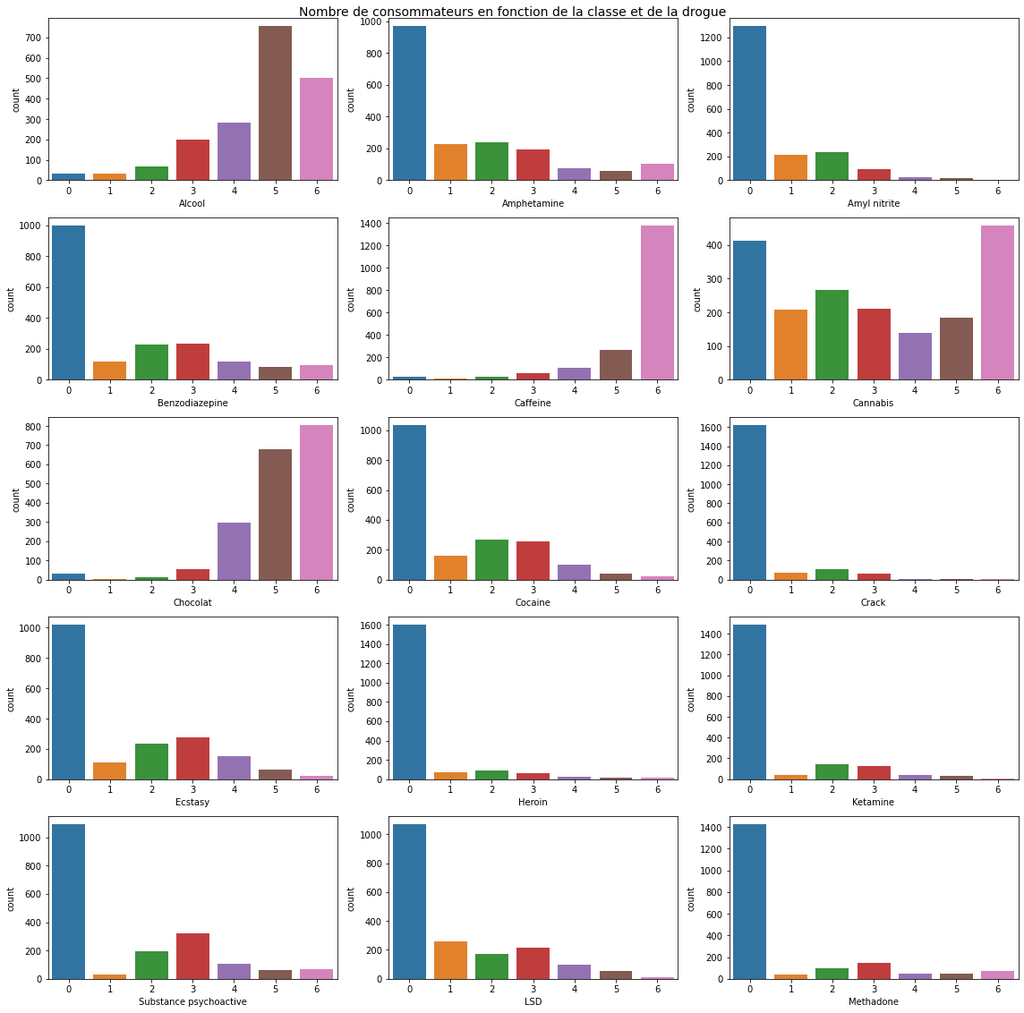

```python
fig, axes = plt.subplots(5,3,figsize = (16,16))
fig.suptitle("Nombre de consommateurs en fonction de la classe et de la drogue",fontsize=14)
k=0
for i in range(5):
    for j in range(3):
        sns.countplot(x=col_drogue[k], data=data,ax=axes[i][j])
        k+=1

plt.tight_layout()
plt.show()
```

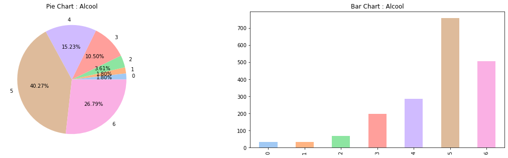

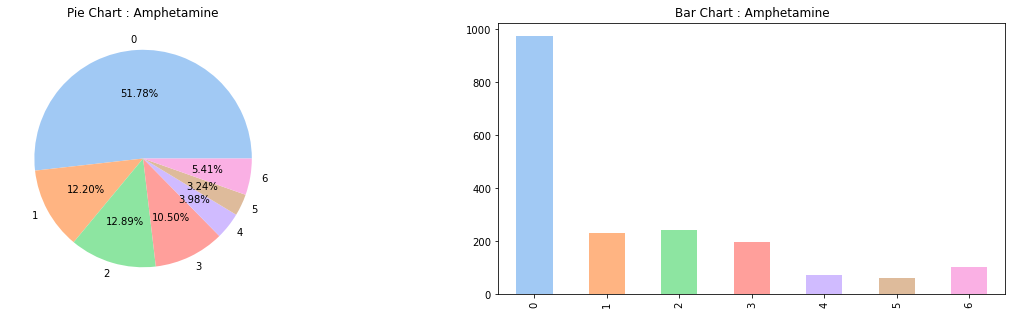

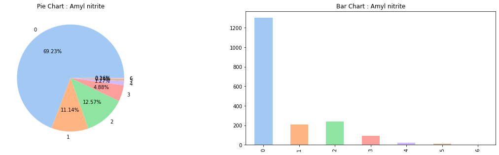

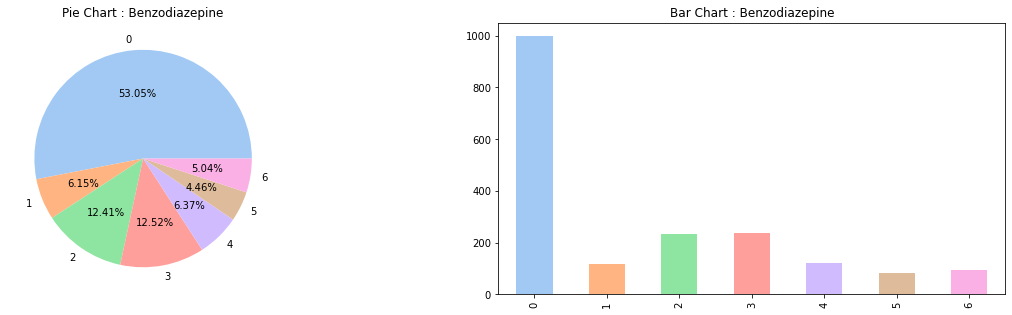

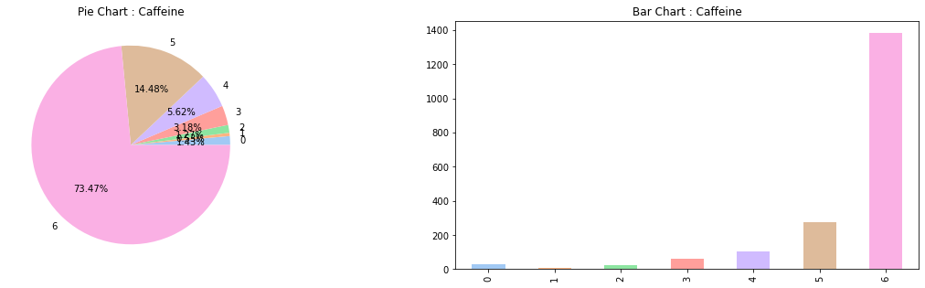

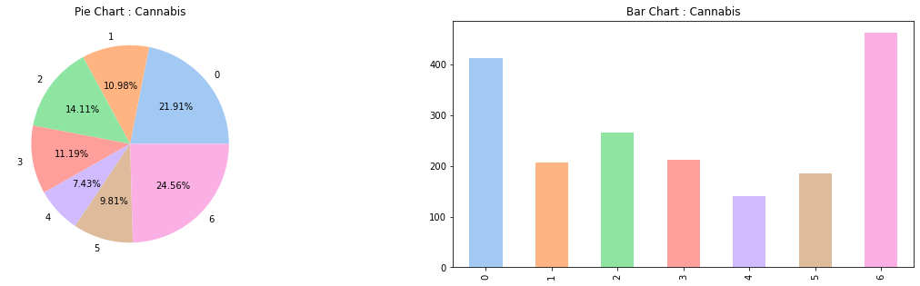

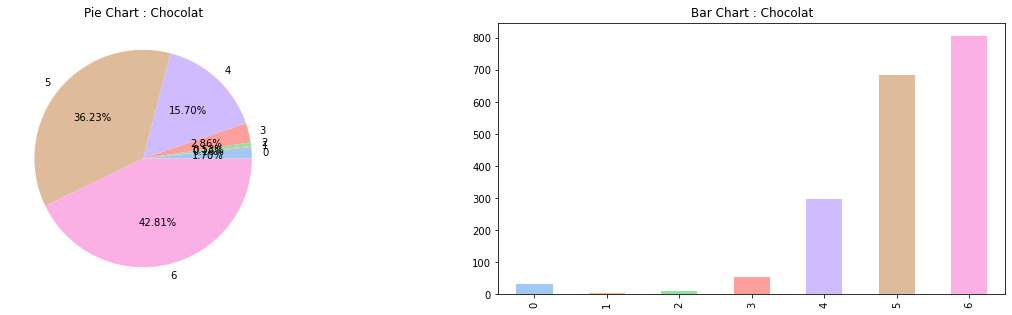

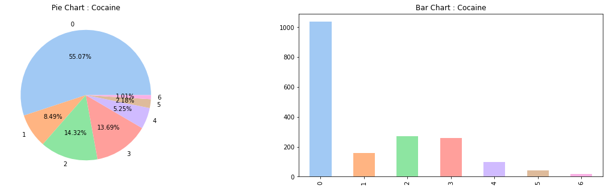

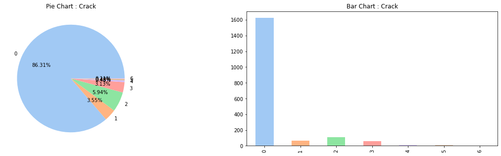

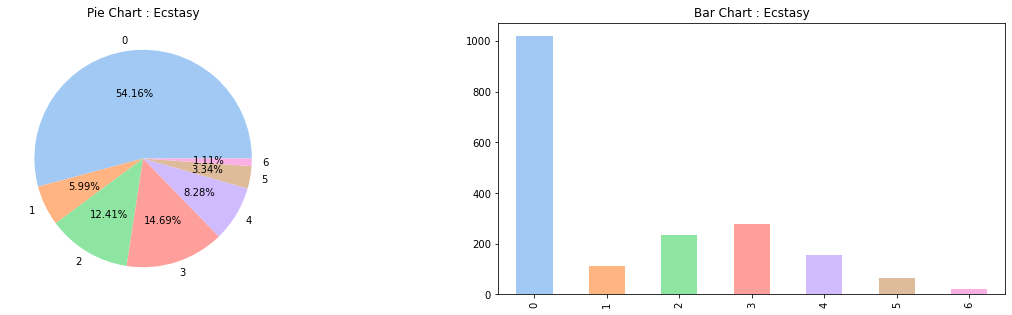

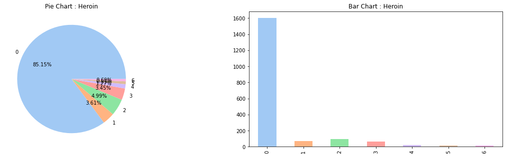

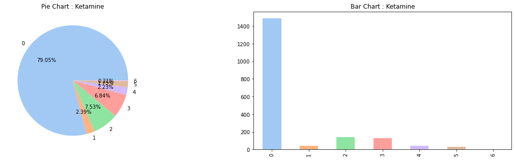

[6 more figures not shown]

```python
visu(df, 'Alcool')
visu(df, 'Amphetamine')
visu(df, 'Amyl nitrite')
visu(df, 'Benzodiazepine')
visu(df, 'Caffeine')
visu(df, 'Cannabis')
visu(df, 'Chocolat')
visu(df, 'Cocaine')
visu(df, 'Crack')
visu(df, 'Ecstasy')
visu(df, 'Heroin')
visu(df, 'Ketamine')
visu(df, 'Substance psychoactive')
visu(df, 'LSD')
visu(df, 'Methadone')
visu(df, 'Champignon hallucinogène')
visu(df, 'Nicotine')
visu(df, 'Substance Volatile')
```

```python
count_regusers = []
count_nonregusers = []
for i in range(len(col_drogue)):
    s = data_regulier.groupby([col_drogue[i]])[col_drogue[i]].count()
    count_regusers.append(s[1])
    count_nonregusers.append(s[0])

trace1 = go.Bar(
    x=col_drogue,
    y=count_regusers,
    name='Déjà testé',
    marker = dict(color="mediumslateblue")
)
trace2 = go.Bar(
    x=col_drogue,
    y=count_nonregusers,
    name='Jamais testé',
    marker = dict(color="lightcoral")
)


datafig = [trace1, trace2]
layout = go.Layout(
    title= 'Nombre de personnes ayant déjà testé ou non chaque drogue',
    yaxis=dict(title='Count', ticklen=5, gridwidth=2),
    barmode='group'
)

fig = go.Figure(data=datafig, layout=layout)
py.iplot(fig, filename='grouped-bar')
```

[interactive chart not shown]

Nous avons pu voir que certaines drogues n'ont jamais été consommées par la majorité des participants (plus de 50%), tandis que d'autres, comme l'alcool, la nicotine ou le cannabis, sont beaucoup plus consommées (régulièrement ou non), et d'autres 'drogues' comme la caféine ou le chocolat sont consommées par presque tous les participants très régulièrement.

#### Corrélation entre les drogues

On remarque quelques corrélations modérées entre certaines drogues sur la heatmap ci-dessous.

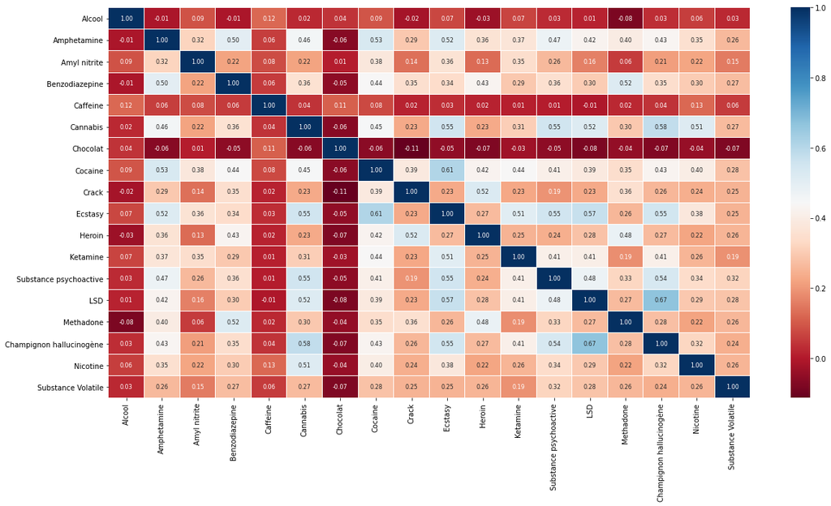

```python
corr = data[col_drogue].corr()
plt.figure(figsize=(20,10))
sns.heatmap(corr, cmap='RdBu',annot=True, annot_kws={"fontsize":8}, linewidth = 0.1, fmt='.2f')
```

#### Corrélations entre les drogues et les caractéristiques démographiques et de personnalité

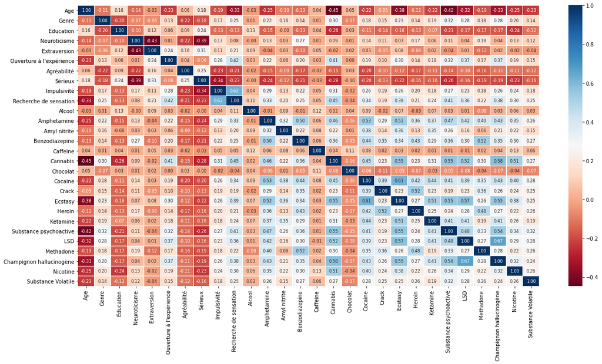

```python
corr = data.corr()
plt.figure(figsize=(20,10))
sns.heatmap(corr, cmap='RdBu',annot=True, annot_kws={"fontsize":8}, linewidth = 0.1, fmt='.2f')
```

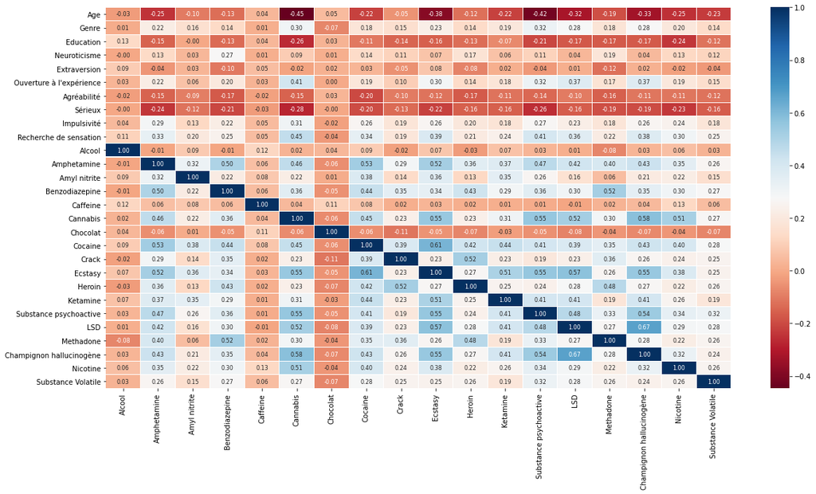

```python
corr = data.corr()[col_drogue]
plt.figure(figsize=(20,10))
sns.heatmap(corr, cmap='RdBu',annot=True, annot_kws={"fontsize":8}, linewidth = 0.1, fmt='.2f')
```

Les valeurs intéressantes sont les corrélations entre la consommation de drogues et les autres caractéristiques (de démographie et de personnalité).

Les caractéristiques démographiques semblent avoir de nombreuses corrélations négatives ou très proches de 0, tandis que certains traits de personnalité semblent avoir des corrélations positives, comme "l'ouverture à l'expérience", "l'impulsivité" ou "la recherche de sensations".

On observe aussi que les corrélations les plus fortes sont entre 2 drogues entre elles : par exemple, la corrélation entre la Cocaïne et l'Ecstasy est de 0,61, et celle entre les champignons hallucinogènes et le LSD est de 0,67.

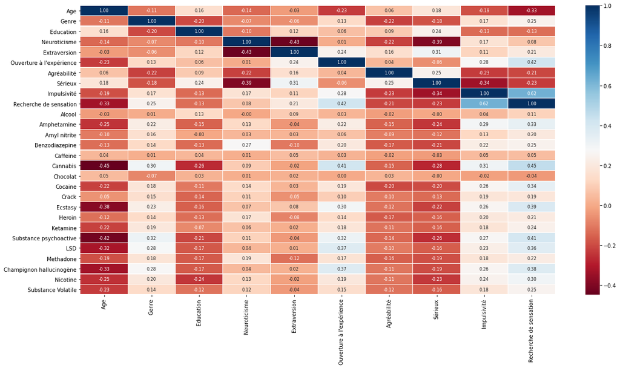

```python
corr = data.corr()[col_démographie+col_personnalité]
plt.figure(figsize=(20,10))
sns.heatmap(corr, cmap='RdBu',annot=True, annot_kws={"fontsize":8}, linewidth = 0.1, fmt='.2f')
```